# MATH1324 Introduction to Statistics Assignment 2

Phil Steinke s3725547

# Modelling Body Measurements

### 2. Load Packages:

```r
suppressPackageStartupMessages(library(readr))
suppressPackageStartupMessages(library(base))
suppressPackageStartupMessages(library(dplyr))
suppressPackageStartupMessages(library(readxl))
suppressPackageStartupMessages(library("mosaic", lib.loc="/Library/Frameworks/R.framework/Versions/3.4/Resources/library"))
setwd("~/code/tldr/data-science/stats-math1324/assignment2")
suppressPackageStartupMessages(library("gridExtra"))
suppressPackageStartupMessages(library("latticeExtra"))
```

### 3. Data: Import the body measurements data and prepare it for analysis.

```r
body_measurements <- read_excel("data/bdims.csv (1).xlsx",
    sheet = "bdims.csv") %>%
  as.data.frame()
```

#### Tidy it up

*define the variable sex as a factor and define labels for it) using R functions.*

```r
wrist_measurements <-
  select(
    body_measurements,
    wri.gi,
    sex) %>%
  as.data.frame()
colnames(wrist_measurements) <-
  c("wrist.girth", "sex")
wrist_measurements <-
  mutate(
    wrist_measurements,
    sex=factor(
      sex,
      labels=c("female", "male"))) %>%
  print()
```

| wrist.girth | sex |
| --- | --- |
| 16.5 | male |
| 17.0 | male |
| 16.9 | male |
| 16.6 | male |
| 18.0 | male |
| 16.9 | male |
| 18.8 | male |
| 18.0 | male |
| 16.5 | male |
| 16.9 | male |

[output cut: 497 more lines]

## 4. Summary Statistics: Calculate descriptive statistics

*Calculate descriptive statistics (i.e., mean, median, standard deviation, first and third quartile, interquartile range, minimum and maximum values) of the selected measurement grouped by sex.*

## Summary of wrist measurements for all sexes

```r
wrist_summary <- wrist_measurements$wrist.girth
summary(wrist_summary)
```

```
   Min. 1st Qu.  Median    Mean 3rd Qu.    Max.
   13.0    15.0    16.1    16.1    17.1    19.6
```

```r
summary_mean <-
  mean(wrist_summary) %>%
  print()
```

```
[1] 16.09744
```

```r
summary_sd <-
  sd(wrist_summary) %>%
  print()
```

```
[1] 1.380931
```

```r
IQR(wrist_summary) # Interquartile Range
```

```
[1] 2.1
```

## Male Summary Statistics

```r
male <- subset(
  wrist_measurements,
  sex == "male"
  )$wrist.girth
summary(male)
```

```
   Min. 1st Qu.  Median    Mean 3rd Qu.    Max.
  14.60   16.50   17.10   17.19   17.85   19.60
```

```r
male_mean <-
  mean(male) %>%
  print()
```

```
[1] 17.19028
```

```r
male_sd <-
  sd(male) %>%
  print()
```

```
[1] 0.9079967
```

```r
IQR(male) # Interquartile Range
```

```
[1] 1.35
```

## Female Summary Statistics

```r
female <- subset(
  wrist_measurements,
  sex == "female"
  )$wrist.girth
summary(female)
```

```
   Min. 1st Qu.  Median    Mean 3rd Qu.    Max.
  13.00   14.50   15.00   15.06   15.60   18.20
```

```r
female_mean <-
  mean(female) %>%
  print()
```

```
[1] 15.05923
```

```r
female_sd <-
  sd(female) %>%
  print()
```

```
[1] 0.8494101
```

```r
IQR(female) # Interquartile Range
```

```
[1] 1.1
```

## 5. Distribution Fitting: histogram with normal distribution overlay

- Compare the empirical distribution of selected body measurement to a normal distribution separately in men and in women

```r
plot.new()
```

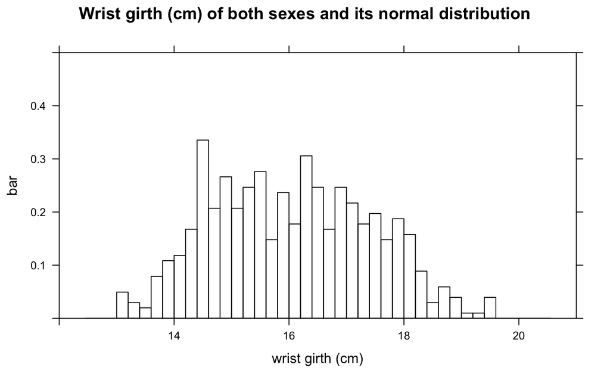

```r
histogram(
  x = wrist_summary,
  type="density",
  main = "Wrist girth (cm) of both sexes and its normal distribution",
  col=rgb(0,0,0,alpha=0.0),
  xlim=c(12,21),
  ylim = c(0,0.50),
  breaks = 40,
  xlab = "wrist girth (cm)",
  ylab = "bar"
  )
```

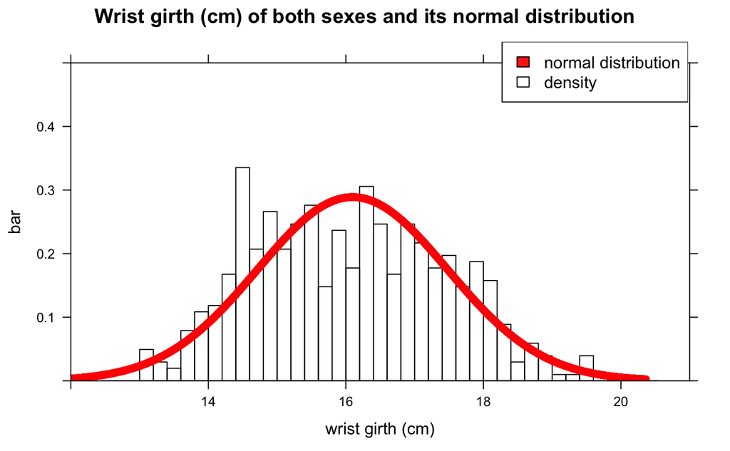

```r
plotDist(
  "norm",
  mean = summary_mean,
  sd = summary_sd,
  kind= "density",
  type = "b",
  col = "red",
  lwd=2,
  add=TRUE,
  xlab = "wrist girth (cm)",
  ylab = "density"
  ) %>%
  return()
legend("topright",
       c("normal distribution", "density"),
       density = c(100, 100),
       fill=c("red","white")
       )
```

- Then you will use R to summarise the empirical distribution of body measurement separately in men and women and compare it to a normal distribution. You need to do this visually by plotting the histogram with normal distribution overlay.

## summarise the empirical distribution of body measurement

## compare it to a normal distribution

- by plotting the histogram with normal distribution overlay

### for men

```r
plot.new()
```

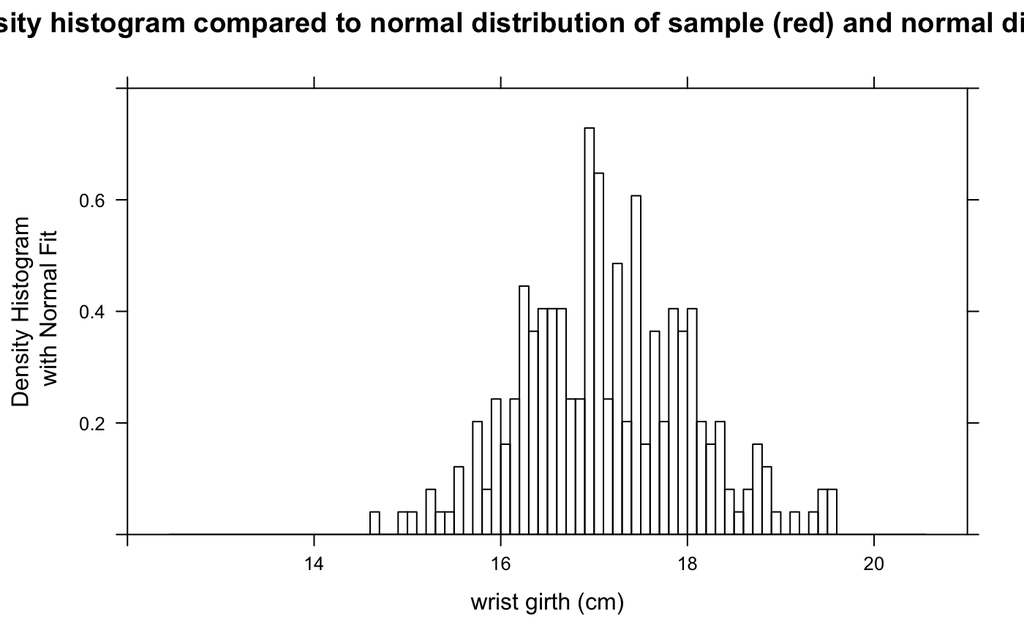

```r
histogram(
  x = male,
  type="density",
  main = "male wrist girth (cm) density histogram compared to normal distribution of sample (red) and normal distribution of males (blue)",  col=rgb(0,0,0,alpha=0.0), xlim=c(12,21), ylim = c(0,0.80),
  breaks = 40,
  xlab = "wrist girth (cm)",
  ylab = "Density Histogram\n with Normal Fit"
  )
```

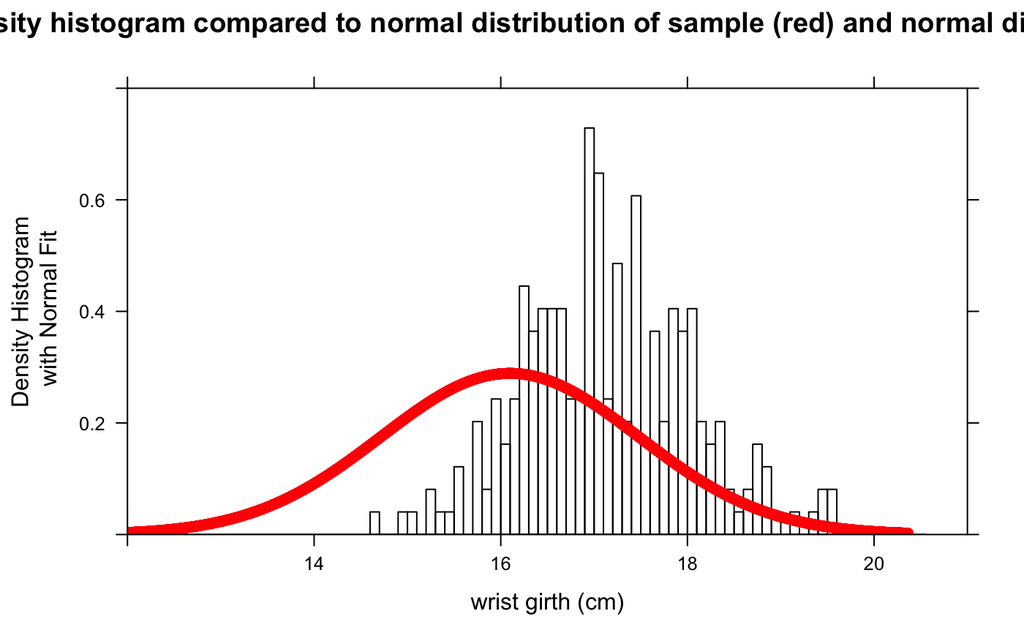

```r
plotDist(
  "norm",
  mean = summary_mean,
  sd = summary_sd,
  kind= "density",
  type = "b",
  col = "red",
  lwd=2,
  add=TRUE,
  xlab = "wrist girth (cm)"
  )
```

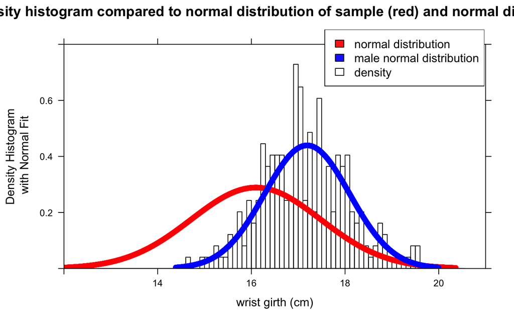

```r
plotDist(
  "norm",
  mean = male_mean,
  sd = male_sd,
  kind= "density",
  type = "b",
  col = "blue",
  lwd=2,
  add=TRUE,
  xlab = "wrist girth (cm)"
  ) %>%
  return()
legend("topright",
       c("normal distribution", "male normal distribution", "density"),
       density = c(100, 100, 100),
       fill=c("red","blue","white")
       )
```

### for females

```r
plot.new()
```

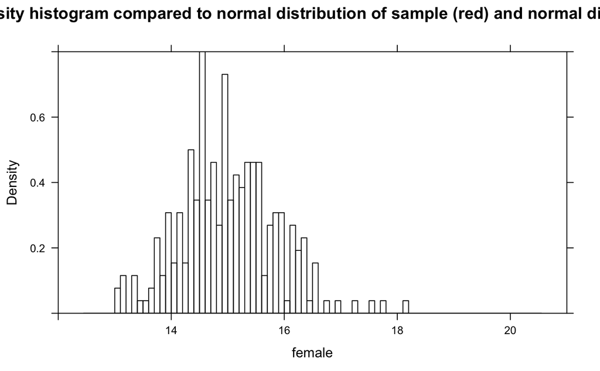

```r
histogram(
  x = female,
  type="density",
  main = "female wrist girth (cm) density histogram compared to normal distribution of sample (red) and normal distribution of females (pink)",
  col=rgb(0,0,0,alpha=0.0), xlim=c(12,21), ylim = c(0,0.80),
  breaks = 40
  )
```

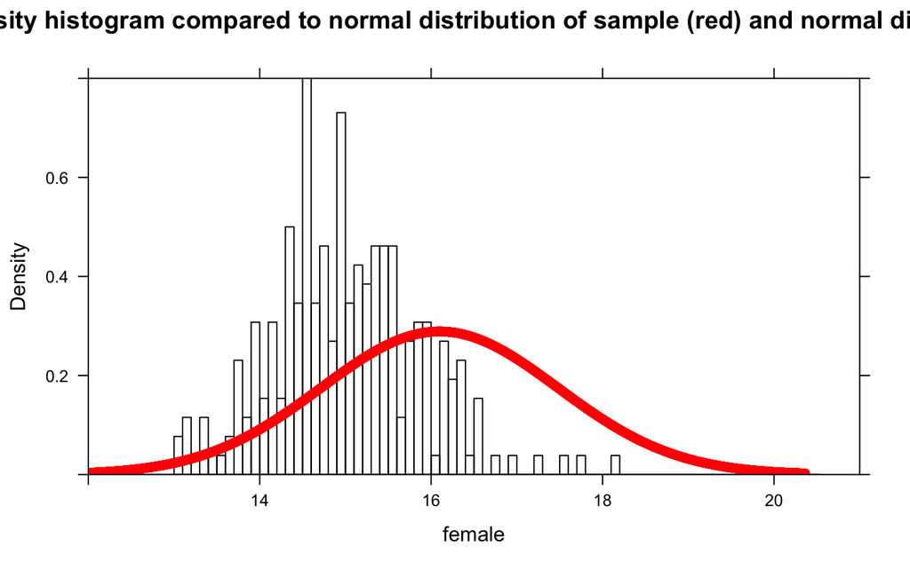

```r
?histogram
plotDist(
  "norm",
  mean = summary_mean,
  sd = summary_sd,
  kind= "density",
  type = "b",
  col = "red",
  lwd=2,
  add=TRUE) %>%
  return()
```

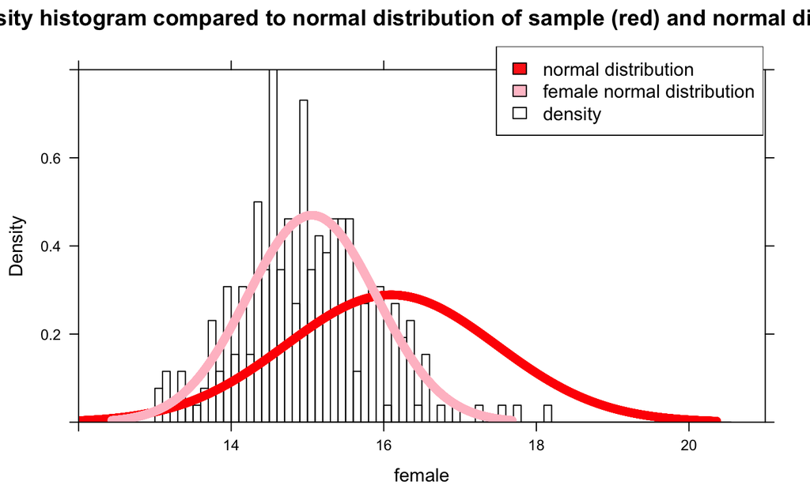

```r
plotDist(
  "norm",
  mean = female_mean,
  sd = female_sd,
  kind= "density",
  type = "b",
  col = "pink",
  lwd=2,
  add=TRUE) %>%
  return()
legend("topright",
       c("normal distribution", "female normal distribution", "density"),
       density = c(100, 100, 100),
       fill=c("red","pink","white")
       )
```

## Interpretation:

### What insight has been gained from the investigation?

- The mean of males is `~17.2cm` and females are `~15cm`
- Median of male is `~17.1cm` and female is `15cm`
- The girth of male wrists are larger than female wrists by an average of `2cm`

### Make recommendations regarding the modelling of this body measurement

- Further analysis to check against other distributions
- Check against the fit with greater and fewer bins